# Trabajo Final EDAED

8 de noviembre de 2017

### Autores

- Mateo Zuluaga  
  ID. 1045026217
- Brahian Gómez  
  ID. 1041234487
- Andrés Acosta  
  ID. 1026154354
- Jose Toquica  
  ID. 1020450656

### Relación entre la longitud del paso la estatura

El siguiente, es un trabajo estadístico, en el que mediante la aplicación “Science Journal” disponible para dispositivos moviles con sistema operativo Android, se puede medir la aceleración en los ejes X, Y y Z del terminal, además de otras mediciones, el experimento consiste en tomar una muestra de personas, que para este trabajo, fueron 62 y se les preguntaba su estatura y género y se les pedia caminar con la teléfono en la mano con la aplicación encendida, a lo largo de una distancia previamente medida, las personas además debían contar el número de pasos que daban.  
Cada conjunto de datos se exporta en formato .csv y con R se saca la longitud del paso de cada persona, esta longitud corresponde a la longitud calculada, también se tiene la longitud de paso real, que es la división de la distancia y el número de pasos que dio la persona, más abájo se analiza este resultado.  
Pero el objetivo principal, es analizar la relación que tiene la estatura de la persona con su longitud de paso calculada discriminado por género, que intiutivamente se pensaría que esta relación es directamente proporcional, es decir que a mayor estatura, mayor será la longitud del paso, hipótesis que se consolidará a continuación.

```
##     lpr.lpc
##  Min.   :0.9558
##  1st Qu.:1.0456
##  Median :1.0833
##  Mean   :1.0907
##  3rd Qu.:1.1192
##  Max.   :1.2783
```

Este es un resumen de la variable longitud_de_paso_real / longitud_de_paso_calulado, en el que se ve que estos datos se centran en la media, que es un valor muy cercano a 1, de lo que se puede concluir que que la longitud real y la calculada son dos valores muy parecidos, lo cual nos da pie a concluir que el calculo de la longitud del paso es bastante preciso, de hecho se pudo observar y concluir que el error se da principalmente por error de las personas al contar los pasos.

```
##     lpc.est
##  Min.   :0.3440
##  1st Qu.:0.3898
##  Median :0.4119
##  Mean   :0.4132
##  3rd Qu.:0.4344
##  Max.   :0.4948
```

```
## $f
##     lpc.est
##  Min.   :0.3580
##  1st Qu.:0.4021
##  Median :0.4126
##  Mean   :0.4175
##  3rd Qu.:0.4350
##  Max.   :0.4598
##
## $m
##     lpc.est
##  Min.   :0.3440
##  1st Qu.:0.3877
##  Median :0.4041
##  Mean   :0.4111
##  3rd Qu.:0.4279
##  Max.   :0.4948
```

Estos 3 resúmenes, se hicieron sobre una variable calculada, que es la longitud del paso calculada dividido la estatura, la primera se hizo a toda la base de datos, donde para las 62 personas se puede observar que se obtiene un valor para la media de 0.4132 con un máximo de 0.4948 y un mínimo de 0.3440, de donde se observa, que hay cierta relación.  
Los dos siguientes resúmenes, se hicieron separando la población femenina (20) de la masculina (42) y se puede ver que los dos valores extremos provienen de la población masculina y que en las mujeres, el intervalo se acorta bastante.

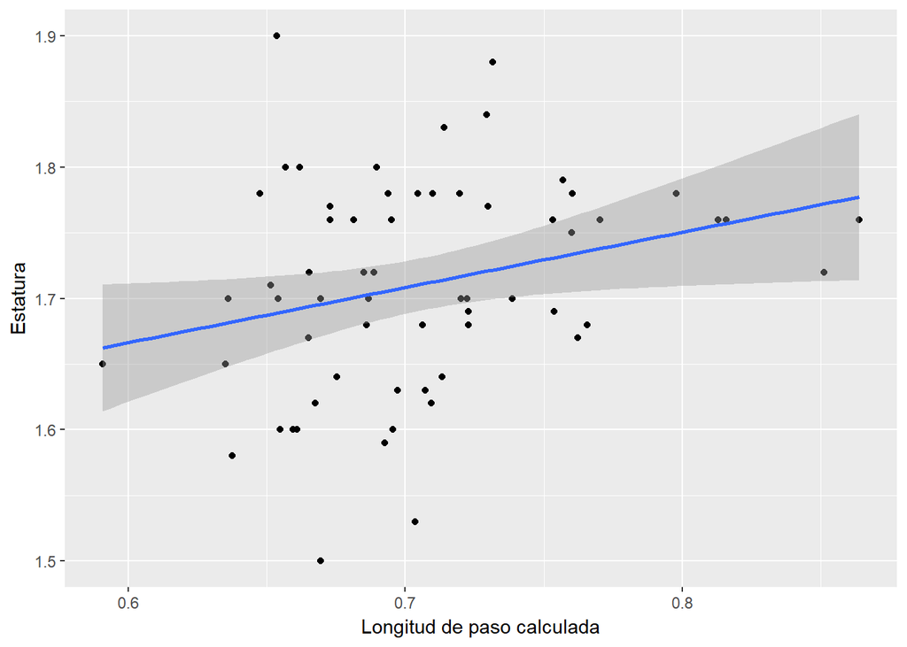

Acá se tiene una gráfica de la longitud de paso contra la estatura, donde a simple vista no se puede notar el creciemiento, pero con la linea de dispersión se ve claramente que a medida de que la estatura tiene a subir, la longitud del paso tambieén tiende a aumentar.

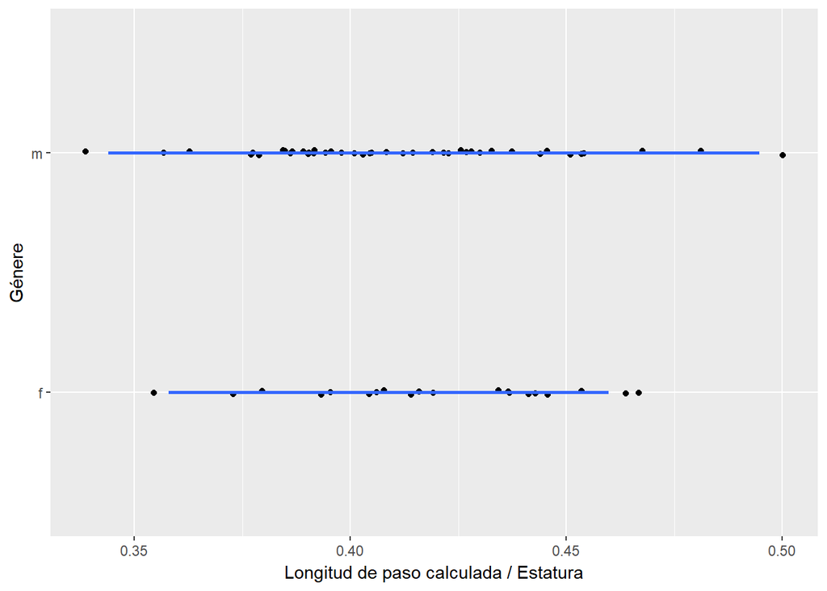

#### Referencias

Aplicación Science Journal  
https://play.google.com/store/apps/details?id=com.google.android.apps.forscience.whistlepunk&hl=es